# Cycle Show Document

#### **零. 前言**

> 自行車展案的目的在於：用科學方法達到自行車展的辦展目的。 從與辦展單位發想的過程中，概括了幾個方向，此份文件分別討論這幾個方向。

#### **一. 協助篩選vip參展商**

> 程式接受一份廠商名單，並回傳此份名單的：
> 1. HS code產品分類出口金額
> 2. 是否為在台製造商
> 3. 是否為500大績優廠商
> 4. 是否為台灣精品得獎廠商

#### **二. 自行車貿易統計公會均依據HS code分三類**

> 自行車Hscode統一以下表為準：

```
##    HsCode   category
## 1  871200       整車
## 2  851210     零組件
## 3  871491     零組件
## 4  871492     零組件
## 5  871493     零組件
## 6  871494     零組件
## 7  871495     零組件
## 8  871496     零組件
## 9  871499     零組件
## 10 731511     零組件
## 11 401150     零組件
## 12 401320     零組件
## 13 871190 電動自行車
```

#### **三. 分析適合配合新南向政策推動的展覽，自行車與體育用品適合成熟歐美市場，非新南向適銷產業**

> 以檔案提供各國進口自行車產品之資料。

#### **四. 五年忠誠參展商出口額變化**

> 將這個問題轉換成，出口額是否影響廠商的忠誠度？

> 首先，將參展商分為兩類：高出口廠商與低出口廠商

> 第二，定義忠誠度。(以下提供兩個示例)

> 第三，檢定：是否高出口類的廠商忠誠度大於低出口類的廠商忠誠度？

```
## [1] "High mean : "
## [1] 3.8
## [1] "Low mean : "
## [1] 3.6
##
##  Kruskal-Wallis rank sum test
##
## data:  ex1[, rfm] and ex1[, fact]
## Kruskal-Wallis chi-squared = 18.57, df = 1, p-value = 1.638e-05
##
##          exp_high
## Frequency FALSE TRUE
##         1   159   46
##         2    89   22
##         3    76    6
##         4    55   11
##         5   406  194
```

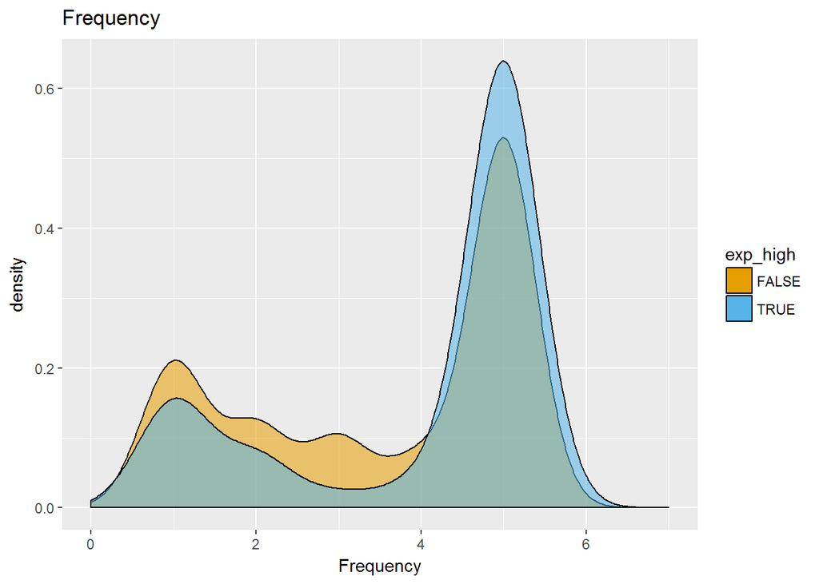

```
## [1] "High mean : "
## [1] 11.46667
## [1] "Low mean : "
## [1] 9.266667
##
##  Kruskal-Wallis rank sum test
##
## data:  ex1[, rfm] and ex1[, fact]
## Kruskal-Wallis chi-squared = 84.134, df = 1, p-value < 2.2e-16
##
##                   exp_high
## RFIndex            FALSE TRUE
##   1                   38   13
##   1.33333333333333    49   17
##   1.66666666666667    20    7
##   2                   31    5
##   2.33333333333333    31    4
##   2.66666666666667    27    7
```

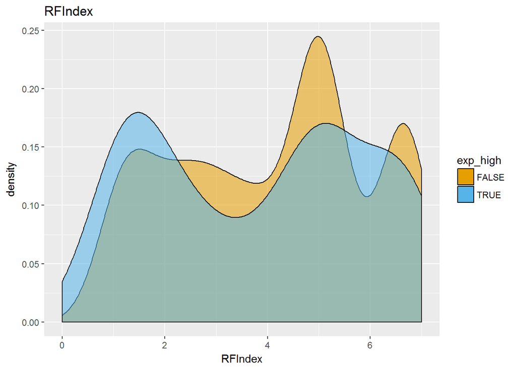

> 結論：採用的兩種忠誠度定義，皆顯示高出口類的廠商忠誠度大於低出口類的廠商忠誠度。

#### **五. 提供有工廠登記與出口實績但過去5年未參展公司名單**

> 以檔案提供。

#### **六. 比較十大買主來源國、忠誠度高之買主來元國與十大進口市場之一致性或前三大買主成長國與進口市場成長率之一致性**

> 什麼變數跟買主來源國的忠誠度有關係？

> 我們蒐集了世界各國的自行車進口、出口等資料，並觀察是否忠誠度與這些變數有關聯。

```
## Call:corr.test(x = DF[, -c(1:9)], y = DF[, 2:7], method = "spearman")
## Correlation matrix
##                       RFIndex2.Min. RFIndex2.1st.Qu. RFIndex2.Median
## 2013_Export_Taiwan            -0.47            -0.19            0.10
## 2013_Export_World             -0.57            -0.16            0.06
## 2013_Import_Taiwan            -0.65            -0.30            0.03
## 2013_Import_World             -0.67            -0.31            0.00
## 2013_Re-Export_Taiwan         -0.11             0.01            0.17
## 2013_Re-Export_World           0.05             0.01           -0.04
## 2013_Re-Import_Taiwan         -0.07            -0.14           -0.14
## 2013_Re-Import_World          -0.21            -0.12            0.05
## 2014_Export_Taiwan            -0.52            -0.19            0.09
## 2014_Export_World             -0.56            -0.17            0.09
## 2014_Import_Taiwan            -0.61            -0.24            0.07
## 2014_Import_World             -0.63            -0.25            0.04
## 2014_Re-Export_Taiwan         -0.13            -0.05            0.09
## 2014_Re-Export_World          -0.07            -0.04            0.01
## 2014_Re-Import_World          -0.25            -0.15            0.01
## 2015_Export_Taiwan            -0.53            -0.20            0.08
## 2015_Export_World             -0.59            -0.18            0.04
## 2015_Import_Taiwan            -0.65            -0.28            0.01
## 2015_Import_World             -0.66            -0.23            0.06
## 2015_Re-Export_Taiwan         -0.11            -0.07            0.10
## 2015_Re-Export_World           0.05            -0.04           -0.03
## 2015_Re-Import_Taiwan         -0.07            -0.14           -0.14
## 2015_Re-Import_World          -0.20            -0.12           -0.01
## 2016_Export_Taiwan            -0.48            -0.26            0.02
## 2016_Export_World             -0.44            -0.21           -0.02
## 2016_Import_Taiwan            -0.51            -0.30           -0.07
## 2016_Import_World             -0.50            -0.25           -0.03
## 2016_Re-Export_Taiwan         -0.13            -0.05            0.09
## 2016_Re-Export_World           0.06            -0.02           -0.01
## 2016_Re-Import_Taiwan         -0.07             0.01           -0.08
## 2016_Re-Import_World          -0.16            -0.09            0.02
## Import_Growth_World           -0.10            -0.06           -0.09
## Import_Growth_Taiwan          -0.11            -0.05           -0.07
## Import_Share_2013             -0.35            -0.14            0.08
## Import_Share_2014             -0.33            -0.10            0.15
## Import_Share_2015             -0.40            -0.24            0.00
## Import_Share_2016             -0.42            -0.26            0.04
```

[output cut: 185 more lines]

```
## 2016_Import_Taiwan             1.00             1.00          0.00
## 2016_Import_World              1.00             1.00          0.00
## 2016_Re-Export_Taiwan          1.00             1.00          1.00
## 2016_Re-Export_World           1.00             1.00          1.00
## 2016_Re-Import_Taiwan          1.00             1.00          1.00
## 2016_Re-Import_World           1.00             1.00          1.00
## Import_Growth_World            1.00             1.00          1.00
## Import_Growth_Taiwan           1.00             1.00          1.00
## Import_Share_2013              0.83             1.00          0.00
## Import_Share_2014              0.14             0.85          0.00
## Import_Share_2015              0.76             1.00          0.00
## Import_Share_2016              1.00             1.00          0.00
## Import_Share_Growth            1.00             1.00          1.00
##
##  To see confidence intervals of the correlations, print with the short=FALSE option
```

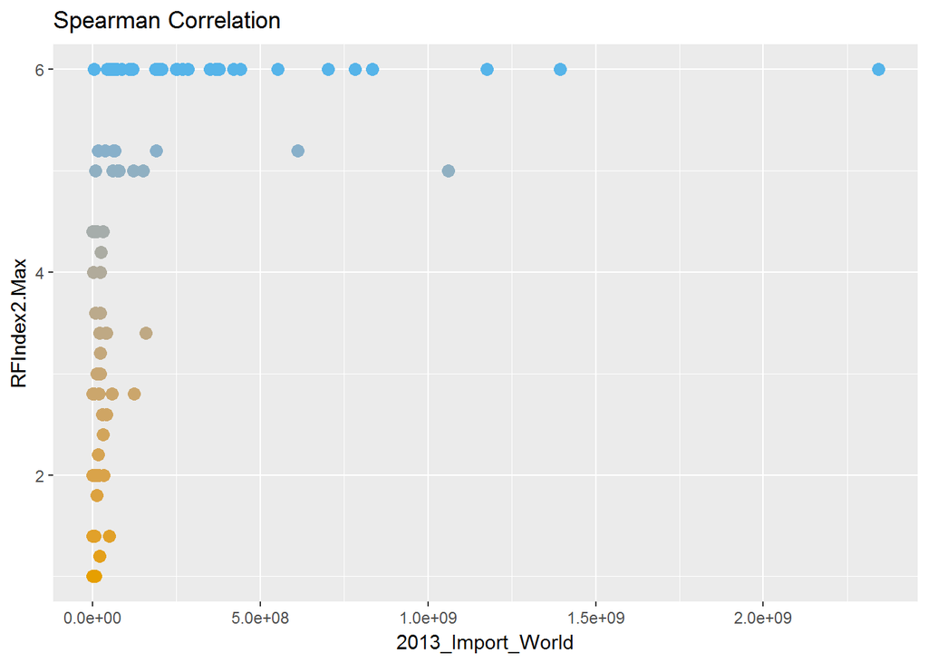

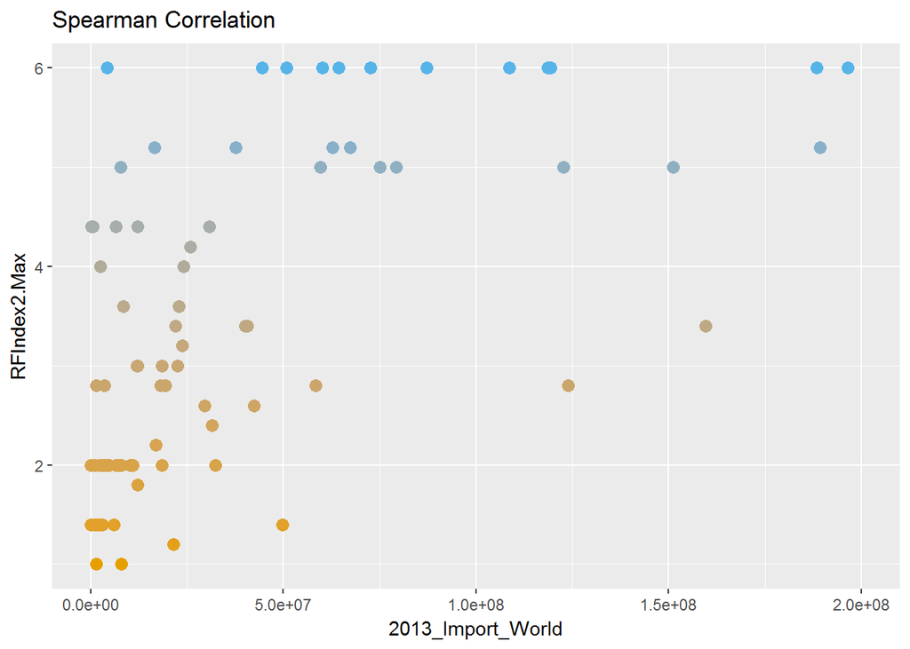

> 可以看見，`RFIndex2.Max.`與各種進出口數據有著比較高的相關性，因此關注其散布圖。然而，一個國家的最忠誠廠商之忠誠度難以反映全體廠商之忠誠度。